# Population dynamics of water birds in BR

Gompertz Stochastic State-Space population models with Poisson error

Orlando Acevedo-Charry

23 June 2025

# 1 Intro

## 1.1 Packages

```r
library(tidyverse)
library(dclone);
```

```
##
##
## dclone 2.3-2      2023-07-02
```

```r
library(mcmcplots)
```

# 2 Data

Update data organized

```r
waterbirds <- read_csv("data/BR_waterbirds_monitoring.csv")
```

Let’s convert in a long format to keep monitoring!!

```r
waterbird_long <- waterbirds |>
  pivot_longer(cols = !c("Original_Date", "Year", "Month", "Day", "Site"),
               names_to = "Species",
               values_to = "Count", values_drop_na = TRUE) |>
  mutate(Date = ymd(paste(Year, Month, Day, sep = "-")))

write_csv(waterbird_long, "data/Monitoring_long_format.csv")
```

To this file, I added other columns to include the information in the previous format of monitoring regarding the survey (participants, activity, environmental conditions, hours of sampling) or the birds (e.g., photos, juveniles, flyovers).

Now we can check that each species should have a single count for each time step in the time series in each site. We can select the maximum count per quarter of year per site in each species, as the minimum number of individuals alive in regular steps of observed abundance:

```r
waterbird_long <- waterbird_long |>
  mutate(Date = floor_date(Date, "quarter")) |>
  dplyr::select(Date, Site, Species, Count) |>
  group_by(Species, Site, Date) |>
  summarise(Count = max(Count)) |>
  as.data.frame()
seq(min(waterbird_long$Date), max(waterbird_long$Date), by = "quarter")
```

```
##  [1] "2004-01-01" "2004-04-01" "2004-07-01" "2004-10-01" "2005-01-01"
##  [6] "2005-04-01" "2005-07-01" "2005-10-01" "2006-01-01" "2006-04-01"
## [11] "2006-07-01" "2006-10-01" "2007-01-01" "2007-04-01" "2007-07-01"
## [16] "2007-10-01" "2008-01-01" "2008-04-01" "2008-07-01" "2008-10-01"
## [21] "2009-01-01" "2009-04-01" "2009-07-01" "2009-10-01" "2010-01-01"
## [26] "2010-04-01" "2010-07-01" "2010-10-01" "2011-01-01" "2011-04-01"
## [31] "2011-07-01" "2011-10-01" "2012-01-01" "2012-04-01" "2012-07-01"
## [36] "2012-10-01" "2013-01-01" "2013-04-01" "2013-07-01" "2013-10-01"
## [41] "2014-01-01" "2014-04-01" "2014-07-01" "2014-10-01" "2015-01-01"
## [46] "2015-04-01" "2015-07-01" "2015-10-01" "2016-01-01" "2016-04-01"
## [51] "2016-07-01" "2016-10-01" "2017-01-01" "2017-04-01" "2017-07-01"
## [56] "2017-10-01" "2018-01-01" "2018-04-01" "2018-07-01" "2018-10-01"
## [61] "2019-01-01" "2019-04-01" "2019-07-01" "2019-10-01" "2020-01-01"
## [66] "2020-04-01" "2020-07-01" "2020-10-01" "2021-01-01" "2021-04-01"
## [71] "2021-07-01" "2021-10-01" "2022-01-01" "2022-04-01" "2022-07-01"
## [76] "2022-10-01" "2023-01-01" "2023-04-01" "2023-07-01" "2023-10-01"
## [81] "2024-01-01" "2024-04-01" "2024-07-01"
```

The entire time series is 83 quarters of year, from March 2004 to July 2024.

## 2.1 Summary of the dataset

How many species? How many months of survey per site have each species?

```r
waterbird_long |>
  group_by(Species,Site,Date) |>
  count() |>
  group_by(Species,Site) |>
  count() |>
  arrange(-n) |>
  pivot_wider(names_from = "Site", values_from = "n",values_fill = 0) |>
  as.data.frame()
```

| Species | Embu | PET | Lagoa Branca Flor |
| --- | --- | --- | --- |
| Himantopus mexicanus melanurus | 54 | 30 | 1 |
| Amazonetta brasiliensis | 52 | 37 | 1 |
| Gallinula galeata | 51 | 38 | 1 |
| Jacana jacana | 49 | 36 | 1 |
| Tringa flavipes | 49 | 26 | 0 |
| Gallinago paraguaiae | 46 | 5 | 0 |
| Anas bahamensis | 45 | 29 | 1 |
| Ardea alba | 43 | 35 | 0 |
| Tringa solitaria | 39 | 17 | 0 |
| Nannopterum brasilianum | 10 | 36 | 0 |

[output cut: 96 more lines]

```r
wtb_ts <- waterbird_long |>
  group_by(Species,Site,Date) |>
  count() |>
  group_by(Species,Site) |>
  count() |>
  filter(n >= 25) |>
  rename(n.time = n) |>
  arrange(-n.time) |>
  as.data.frame()
wtb_ts
```

| Species | Site | n.time |
| --- | --- | --- |
| Himantopus mexicanus melanurus | Embu | 54 |
| Amazonetta brasiliensis | Embu | 52 |
| Gallinula galeata | Embu | 51 |
| Jacana jacana | Embu | 49 |
| Tringa flavipes | Embu | 49 |
| Gallinago paraguaiae | Embu | 46 |
| Anas bahamensis | Embu | 45 |
| Ardea alba | Embu | 43 |
| Tringa solitaria | Embu | 39 |
| Gallinula galeata | PET | 38 |

[output cut: 20 more lines]

```r
unique(wtb_ts$Species)
```

```
##  [1] "Himantopus mexicanus melanurus" "Amazonetta brasiliensis"
##  [3] "Gallinula galeata"              "Jacana jacana"
##  [5] "Tringa flavipes"                "Gallinago paraguaiae"
##  [7] "Anas bahamensis"                "Ardea alba"
##  [9] "Tringa solitaria"               "Nannopterum brasilianum"
## [11] "Egretta thula"                  "Vanellus chilensis"
## [13] "Ardea ibis"                     "Butorides striata"
## [15] "Pardirallus nigricans"          "Anhinga anhinga"
## [17] "Coragyps atratus"               "Aramus guarauna"
## [19] "Dendrocygna bicolor"            "Dendrocygna viduata"
## [21] "Tringa melanoleuca"             "Nycticorax nycticorax"
```

```r
wtb_tsSS <- waterbird_long |>
  left_join(wtb_ts) |>
  filter(!is.na(n.time)) |>
  group_by(Site, Species) |>
  arrange(Date) |>
  as.data.frame()
head(wtb_tsSS)
```

|  | Species | Site | Date | Count | n.time |
| --- | --- | --- | --- | --- | --- |
| 1 | Amazonetta brasiliensis | Embu | 2004-01-01 | 2 | 52 |
| 2 | Ardea alba | Embu | 2004-01-01 | 2 | 43 |
| 3 | Egretta thula | Embu | 2004-01-01 | 4 | 35 |
| 4 | Gallinula galeata | Embu | 2004-01-01 | 5 | 51 |
| 5 | Himantopus mexicanus melanurus | Embu | 2004-01-01 | 44 | 54 |
| 6 | Jacana jacana | Embu | 2004-01-01 | 2 | 49 |

```r
tail(wtb_tsSS)
```

|  | Species | Site | Date | Count | n.time |
| --- | --- | --- | --- | --- | --- |
| 1088 | Gallinago paraguaiae | Embu | 2024-07-01 | 4 | 46 |
| 1089 | Gallinula galeata | Embu | 2024-07-01 | 75 | 51 |
| 1090 | Himantopus mexicanus melanurus | Embu | 2024-07-01 | 6 | 54 |
| 1091 | Jacana jacana | Embu | 2024-07-01 | 2 | 49 |
| 1092 | Pardirallus nigricans | Embu | 2024-07-01 | 2 | 32 |
| 1093 | Vanellus chilensis | Embu | 2024-07-01 | 52 | 35 |

Now we have the observed time series for the species with better data. Let see the counts of the top-5 species with more data

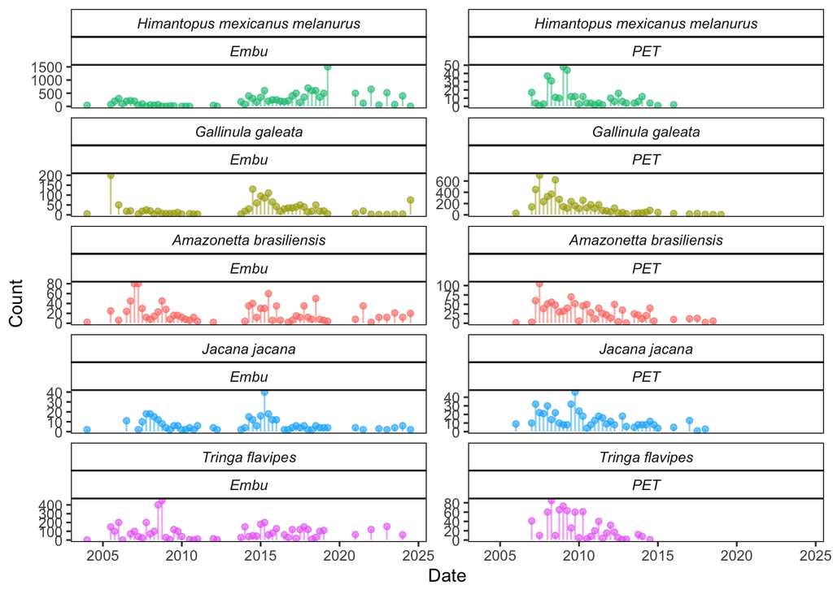

```r
wtb_tsSS |>
  filter(Species %in% c("Himantopus mexicanus melanurus",
                        "Gallinula galeata",
                        "Amazonetta brasiliensis",
                        "Jacana jacana",
                        "Tringa flavipes")) |>
ggplot(aes(x = Date, y = Count, color = Species)) +
  facet_wrap(factor(Species,
                    levels = c("Himantopus mexicanus melanurus",
                        "Gallinula galeata",
                        "Amazonetta brasiliensis",
                        "Jacana jacana",
                        "Tringa flavipes"))~Site,
             scales = "free_y", ncol = 2) +
  geom_segment(aes(y = 0,
                   yend = Count),
               alpha = 0.5)+
  geom_point(alpha = 0.6) +
  theme_bw() +
  theme(legend.position = "none",
        panel.grid.major = element_blank(),
        panel.grid.minor = element_blank(),
        strip.text.x = element_text(face = "italic"),
        strip.background = element_rect(colour = "black", fill = NA),
        panel.border = element_rect(colour = "black", fill = NA))
```

## 2.2 Prepare the time series for Data cloning

```r
prepare_dc_data_list <- function(df) {

  # Create full date sequence
  full_dates <- seq(min(df$Date), max(df$Date), by = "quarter")

  # Expand grid of all combinations
  full_grid <- expand.grid(Date = full_dates,
                           Site = unique(df$Site),
                           Species = unique(df$Species),
                           stringsAsFactors = FALSE)

  # Merge and sort
  df_full <- full_grid |>
    left_join(df, by = c("Date", "Site", "Species")) |>
    arrange(Site, Species, Date)

  # Extract quarter of the year for grouping
  df_full <- df_full |>
    mutate(Date = floor_date(Date, "quarter"))

  # Nest by Site and Species
  nested <- df_full |>
    group_by(Site, Species) |>
    summarise(ts = list(Count), .groups = "drop") |>
    mutate(name = paste(Site, Species, sep = "_"))

  # Create named list of time series
  Y1_list <- set_names(nested$ts, nested$name)

  # Filter out time series that are all NA
  Y1_list <- Y1_list[!map_lgl(Y1_list, ~ all(is.na(.x)))]

  # Vector of time series lengths
  Tvec <- map_int(Y1_list, length)

  return(list(
    Y1 = Y1_list,
    Tvec = Tvec
  ))
}
```

```r
dc_data <- prepare_dc_data_list(wtb_tsSS)
str(dc_data)
```

```
## List of 2
##  $ Y1  :List of 30
##   ..$ Embu_Amazonetta brasiliensis       : num [1:83] 2 NA NA NA NA NA 25 NA 6 NA ...
##   ..$ Embu_Anas bahamensis               : num [1:83] NA NA NA NA NA NA 24 NA 4 2 ...
##   ..$ Embu_Ardea alba                    : num [1:83] 2 NA NA NA NA NA NA NA NA NA ...
##   ..$ Embu_Ardea ibis                    : num [1:83] NA NA NA NA NA NA NA NA NA NA ...
##   ..$ Embu_Coragyps atratus              : num [1:83] NA NA NA NA NA NA NA NA NA NA ...
##   ..$ Embu_Egretta thula                 : num [1:83] 4 NA NA NA NA NA NA NA NA NA ...
##   ..$ Embu_Gallinago paraguaiae          : num [1:83] NA NA NA NA NA NA NA NA NA 5 ...
##   ..$ Embu_Gallinula galeata             : num [1:83] 5 NA NA NA NA NA 200 NA 50 NA ...
##   ..$ Embu_Himantopus mexicanus melanurus: num [1:83] 44 NA NA NA NA NA 74 200 300 100 ...
##   ..$ Embu_Jacana jacana                 : num [1:83] 2 NA NA NA NA NA NA NA NA NA ...
##   ..$ Embu_Pardirallus nigricans         : num [1:83] NA NA NA NA NA NA NA NA NA NA ...
##   ..$ Embu_Tringa flavipes               : num [1:83] 1 NA NA NA NA NA 150 100 200 1 ...
##   ..$ Embu_Tringa melanoleuca            : num [1:83] 14 NA NA NA NA NA 300 200 200 NA ...
##   ..$ Embu_Tringa solitaria              : num [1:83] NA NA NA NA NA NA 1 NA 1 NA ...
##   ..$ Embu_Vanellus chilensis            : num [1:83] 12 NA NA NA NA NA 150 NA 80 NA ...
##   ..$ PET_Amazonetta brasiliensis        : num [1:83] NA NA NA NA NA NA NA NA 1 NA ...
##   ..$ PET_Anas bahamensis                : num [1:83] NA NA NA NA NA NA NA NA 1 NA ...
##   ..$ PET_Anhinga anhinga                : num [1:83] NA NA NA NA NA NA NA NA 1 NA ...
##   ..$ PET_Aramus guarauna                : num [1:83] NA NA NA NA NA NA NA NA 11 NA ...
##   ..$ PET_Ardea alba                     : num [1:83] NA NA NA NA NA NA NA NA 4 NA ...
##   ..$ PET_Butorides striata              : num [1:83] NA NA NA NA NA NA NA NA 3 NA ...
##   ..$ PET_Dendrocygna bicolor            : num [1:83] NA NA NA NA NA NA NA NA 4 NA ...
##   ..$ PET_Dendrocygna viduata            : num [1:83] NA NA NA NA NA NA NA NA 1 NA ...
##   ..$ PET_Egretta thula                  : num [1:83] NA NA NA NA NA NA NA NA 5 NA ...
##   ..$ PET_Gallinula galeata              : num [1:83] NA NA NA NA NA NA NA NA 29 NA ...
##   ..$ PET_Himantopus mexicanus melanurus : num [1:83] NA NA NA NA NA NA NA NA NA NA ...
##   ..$ PET_Jacana jacana                  : num [1:83] NA NA NA NA NA NA NA NA 9 NA ...
##   ..$ PET_Nannopterum brasilianum        : num [1:83] NA NA NA NA NA NA NA NA NA NA ...
##   ..$ PET_Nycticorax nycticorax          : num [1:83] NA NA NA NA NA NA NA NA NA NA ...
##   ..$ PET_Tringa flavipes                : num [1:83] NA NA NA NA NA NA NA NA NA NA ...
##  $ Tvec: Named int [1:30] 83 83 83 83 83 83 83 83 83 83 ...
##   ..- attr(*, "names")= chr [1:30] "Embu_Amazonetta brasiliensis" "Embu_Anas bahamensis" "Embu_Ardea alba" "Embu_Ardea ibis" ...
```

# 3 Gompertz State Space model

## 3.1 Theory and math

You can see [Dennis *et al.* (1991)](https://esajournals.onlinelibrary.wiley.com/doi/10.2307/1943004), [Dennis & Taper (1994)](https://doi.org/10.2307/2937041), [Dennis & Otten (2000)](https://www.jstor.org/stable/pdf/3803237.pdf), [Dennis *et al.*, (2006)](https://esajournals.onlinelibrary.wiley.com/doi/10.1890/0012-9615%282006%2976%5B323%3Aeddpna%5D2.0.co%3B2), [Dennis & Ponciano (2014)](https://esajournals.onlinelibrary.wiley.com/doi/abs/10.1890/13-1486.1), [Ponciano *et al.* (2018)](https://doi.org/10.1016/j.tpb.2018.04.002), and [Evans *et al.* (2022)](https://onlinelibrary.wiley.com/doi/full/10.1111/ibi.13105) for similar models. In addition, interesting readings about State-Space models for population ecology include [Newman *et al.* (2014)](https://doi.org/10.1007/978-1-4939-0977-3), [Newman *et al.* (2023)](https://doi.org/10.1111/2041-210X.13833), or [Auger-Méthe *et al.* (2021)](https://doi.org/10.1002/ecm.1470). We used the Gompertz model because it represent similar estimates of probability of extinction than complex models including Stage or Age-Structure ([Taper *et al.*, 2008](https://link.springer.com/article/10.1007/s11229-007-9299-x)).

The ecological process (State) model for species $i$ in site $m$ (indices not included) is:

$$N_{t+1} = N_{t}\times\exp\left\{a + b\times\ln\,N_{t} + E_{t} \right\},\\\quad E_{t} \sim \text{Normal}(0,\sigma^2).$$
where $N_{t+1}$ is the population size for next time, that came from the previous population size ($N_t$) scaled by the exponential function of a constant that represents intrinsic population growth rate ($a$), another constant that represents the strength of density dependence ($b$) with a no linear relationship with previous population size ($\ln\ N_t$), and the stochasticity of the process ($E_t$), which is a random process assumed to be from a normal distribution and variation $\sigma^2$ (environmental noise).

In the log scale ($X_t = \ln\,N_t$), the model is:

$$X_{t+1} = X_{t} + a + b\times X_{t} + E_{t},\\\quad E_{t} \sim \text{Normal}(0,\sigma^2).$$

or simplified as:

$$X_{t+1} = a + X_{t}\times (1+b) + E_{t},\\\quad c=1+b ,\\\quad E_{t} \sim \text{Normal}(0,\sigma^2).$$

The State-Space model is completed with the observation process, where the observed counts ($Y_t$) are assumed to follow a Poisson distribution with mean $\lambda_t$, which is the exponential of the latent log-abundance state ($X_t$). Thus, the expected count is:

$$Y_t \sim \text{Poisson}(\lambda_t),\quad \lambda_t = e^{X_t}=N_t$$

This formulation links the latent (unobserved) population size $N_t$ to the observed data $Y_t$, assuming that counts are noisy realizations of the true abundance.

## 3.2 Coding the model and test with a single species in a site

Coding the model, including data cloning for diagnostics of estimability of parameters (MLEs) using MCMC methods (see [Lele *et al.*, 2007](https://onlinelibrary.wiley.com/doi/full/10.1111/j.1461-0248.2007.01047.x), [Lele *et al.*, 2010](https://www.math.ualberta.ca/~slele/publications/Lele%20et%20al%20GLMM%202010.pdf), [Sólymos, 2010](https://journal.r-project.org/archive/2010/RJ-2010-011/index.html)):

```r
StochGSS.dc <- function(){

  # Priors on model parameters. Priors are DC1 in Lele et al (2007)
  a1 ~ dnorm(0,1);   # constant, the population growth rate.
  c1 ~ dunif(-1,1);      # constant, the density dependence parameter.
  sig1 ~ dlnorm(-0.5,10); #variance parameter of stochastic  environment (process noise) in the system
  stovar1 <- 1/pow(sig1,2)
#  tau1 ~ dunif(0,1); # detection probability (scaling factor that adjust expected counts to imperfect detection or measurement error)

  for(k in 1:K){
    # Simulate trajectory that depends on the previous
    mean_X1[1,k] <- a1/(1-c1) # Expected value of the first realization of the process
    # this is drawn from the stationary distribution of the process
    # Equation 14 (main text) and  A.4 in Appendix of Dennis et al 2006
    Varno1[k] <- pow(sig1,2)/(1-pow(c1,2)) #. Equation A.5 in Appendix of Dennis et al 2006

    # Updating the state: Stochastic process for all time steps
    X1[1,k]~dnorm(mean_X1[1,k], 1/Varno1[k]); #first estimation of population

    #iteration of the GSS model in the data
    for (t in 2:qp1) {
      mean_X1[t,k] <- a1 + c1 * X1[(t - 1),k]
      X1[t,k] ~ dnorm(mean_X1[t,k], stovar1) # Et is included here since a+cX(t-1) + Et ~ Normal(a+cX(t-1),sigma^2)
    }

    # Updating the observations, from the counts under Poisson observation error
      # incorporating detection probability directly into the Poisson mean
    for (t in 1:qp1) {
      Y1[t,k] ~ dpois(exp(X1[t,k]));
    }
  }
}
```

Trying to include the detection probability as a scale factor adjusting the expected counts to imperfect detection $Y_t \sim \text{Poisson}(\tau \times \lambda_t)$ resulted in estimability issues, cautioned the issue of including that additional parameter in the model (see [Lele et al. 2010](https://esajournals.onlinelibrary.wiley.com/doi/abs/10.1890/10-0099.1)).

```r
dcrun.GSS.tau <- readRDS("data/test_dcfitGSS_tau.rds")

summary(dcrun.GSS.tau); # see R-hat for tau1 and a1 !!!
```

```
##
## Iterations = 50110:150100
## Thinning interval = 10
## Number of chains = 3
## Sample size per chain = 10000
## Number of clones = 20
##
## 1. Empirical mean and standard deviation for each variable,
##    plus standard error of the mean:
##
##        Mean      SD   DC SD  Naive SE Time-series SE R hat
## a1   1.2582 0.14722 0.65841 0.0008500      0.0063646 1.449
## c1   0.7625 0.01904 0.08513 0.0001099      0.0002316 1.000
## sig1 1.1027 0.02667 0.11927 0.0001540      0.0001670 1.000
## tau1 0.4711 0.21942 0.98127 0.0012668      0.0704160 2.007
##
## 2. Quantiles for each variable:
##
##        2.5%    25%    50%    75%  97.5%
## a1   0.9767 1.1558 1.2579 1.3577 1.5463
## c1   0.7245 0.7497 0.7628 0.7754 0.7991
## sig1 1.0518 1.0844 1.1023 1.1204 1.1562
## tau1 0.2245 0.3005 0.4163 0.5523 0.9816
```

```r
dcdiag(dcrun.GSS.tau) # R-hat away of ~1!!!
```

|  | n.clones | lambda.max | ms.error | r.squared | r.hat |
| --- | --- | --- | --- | --- | --- |
| 1 | 1 | 0.17094059 | 0.20954678 | 0.0225043647 | 1.399448 |
| 2 | 5 | 0.16090263 | 0.22773968 | 0.0281681974 | 2.298117 |
| 3 | 10 | 0.08003007 | 0.29714224 | 0.0291640975 | 3.432287 |
| 4 | 20 | 0.06014276 | 0.03773716 | 0.0008604566 | 1.915950 |

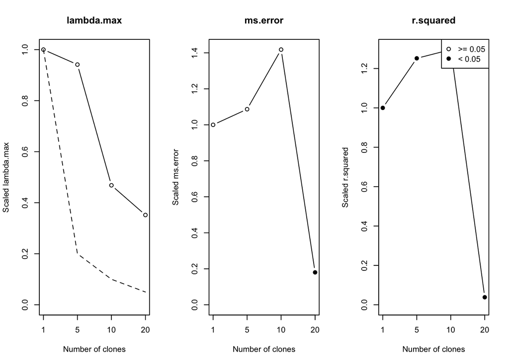

```r
plot(dcdiag(dcrun.GSS.tau)) # mean squared error and r^2 increasing from 1-10 clones
```

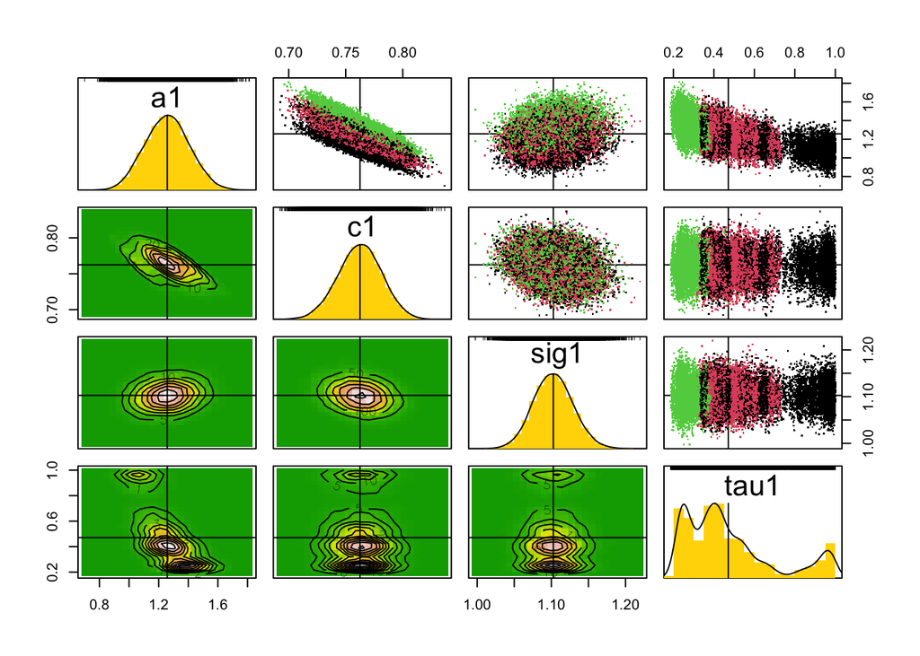

```r
pairs(dcrun.GSS.tau) # it seems tau is the problem
```

```r
coef(dcrun.GSS.tau)
```

```
##        a1        c1      sig1      tau1
## 1.2581637 0.7624916 1.1026925 0.4711283
```

For this model, we will need some initial values of the parameters, and given that there are many `NA` a wrap to provide those initial guess values.

```r
guess.calc <- function(Yobs,Tvec){

  T.t <-Tvec-Tvec[1]; #  For calculations, time starts at zero.
  q <- length(Yobs)-1;      #  Number of time series transitions, q.
  qp1 <- q+1;              #  q+1 gets used a lot, too.
  S.t <- T.t[2:qp1]-T.t[1:q];  #  Time intervals.
  Ybar <- mean(Yobs);
  Yvar <- sum((Yobs-Ybar)*(Yobs-Ybar))/q;
  mu1 <- Ybar;

  # Kludge an initial value for theta based on mean of Y(t+s) given Y(t).
  th1<- -mean(log(abs((Yobs[2:qp1]-mu1)/(Yobs[1:q]-mu1)))/S.t);
  bsq1<- 2*th1*Yvar/(1+2*th1);         # Moment estimate using stationary
  tsq1<- bsq1;                         #   variance, with betasq=tausq.

  #three 0's
  three0s <- sum(c(th1,bsq1,tsq1))
  if(three0s==0|is.na(three0s)){th1 <- 0.5;bsq1 <- 0.09; tsq1 <- 0.23;}


  out1 <- c(th1,bsq1,tsq1);
  if(sum(out1<1e-7)>=1){out1 <- c(0.5,0.09,0.23)}
  out <- c(mu1,out1);
  return(abs(out))

}

guess.calc2.0<- function(TimeAndNs){

  newmat <- TimeAndNs
  isnas <- sum(is.na(TimeAndNs))

  if(isnas >= 1){

    isnaind <- which(is.na(TimeAndNs[,2]), arr.ind=TRUE)
    newmat <- TimeAndNs[-isnaind,]
    newmat[,1] <- newmat[,1] - newmat[1,1]

  }

  init.guess <- guess.calc(Yobs = log(newmat[,2]), Tvec=newmat[,1])

  mu1  <- init.guess[1]
  th1  <- init.guess[2]
  bsq1 <- init.guess[3]
  sigsq1<- ((1-exp(-2*th1))*bsq1)/(2*th1)

  out <- c(mu=mu1, theta=th1, sigmasq = sigsq1)
  return(out)
}
```

And we have to bundle the data for Data cloning. Let’s fit the first species in the taxa with higher data (*Himantopus mexicanus melanurus* in Embu) as a test.

```r
ts.4guess  <- dc_data$Y1[[9]] # this is Himantopus mexicanus in Embu
tvec4guess  <- 1:length(ts.4guess)
onets4guess <- cbind(tvec4guess, ts.4guess)
naive.guess <- guess.calc2.0(TimeAndNs = onets4guess)

datalistGSS.dc <- list(K = 1,
                       qp1 = length(ts.4guess),
                       Y1 = dcdim(array(ts.4guess,
                                        dim = c(length(ts.4guess),1))))

dcrun.GSS <- dc.fit(data = datalistGSS.dc,
                    params = c("a1", "c1", "sig1"), # previous attempt with tau1
                    model = StochGSS.dc,
                    n.clones = c(1,5,10,20),
                    multiply = "K",
                    unchanged = "qp1",
                    n.chains = 3,
                    n.adapt = 50000,
                    n.update = 100,
                    thin = 10,
                    n.iter = 100000)

saveRDS(dcrun.GSS, "data/test_dcfitGSS.rds")
```

```r
dcrun.GSS <- readRDS("data/test_dcfitGSS.rds")

summary(dcrun.GSS);
```

```
##
## Iterations = 50110:150100
## Thinning interval = 10
## Number of chains = 3
## Sample size per chain = 10000
## Number of clones = 20
##
## 1. Empirical mean and standard deviation for each variable,
##    plus standard error of the mean:
##
##        Mean      SD  DC SD  Naive SE Time-series SE R hat
## a1   1.0612 0.09345 0.4179 0.0005396      0.0010200     1
## c1   0.7615 0.01941 0.0868 0.0001121      0.0002144     1
## sig1 1.1026 0.02691 0.1203 0.0001553      0.0001715     1
##
## 2. Quantiles for each variable:
##
##        2.5%    25%    50%    75%  97.5%
## a1   0.8809 0.9983 1.0600 1.1228 1.2507
## c1   0.7228 0.7487 0.7617 0.7748 0.7989
## sig1 1.0513 1.0844 1.1021 1.1205 1.1567
```

```r
dcdiag(dcrun.GSS)
```

|  | n.clones | lambda.max | ms.error | r.squared | r.hat |
| --- | --- | --- | --- | --- | --- |
| 1 | 1 | 0.132120473 | 0.152497086 | 0.0157155927 | 1.000289 |
| 2 | 5 | 0.034557750 | 0.007769124 | 0.0009813383 | 1.000126 |
| 3 | 10 | 0.017840307 | 0.003932356 | 0.0005146385 | 1.000434 |
| 4 | 20 | 0.009118591 | 0.002446845 | 0.0002522309 | 1.000291 |

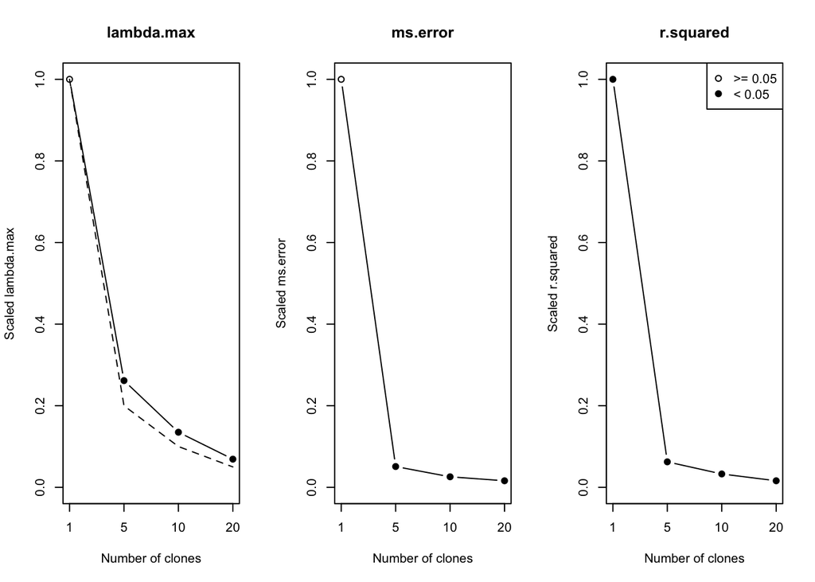

```r
plot(dcdiag(dcrun.GSS))
```

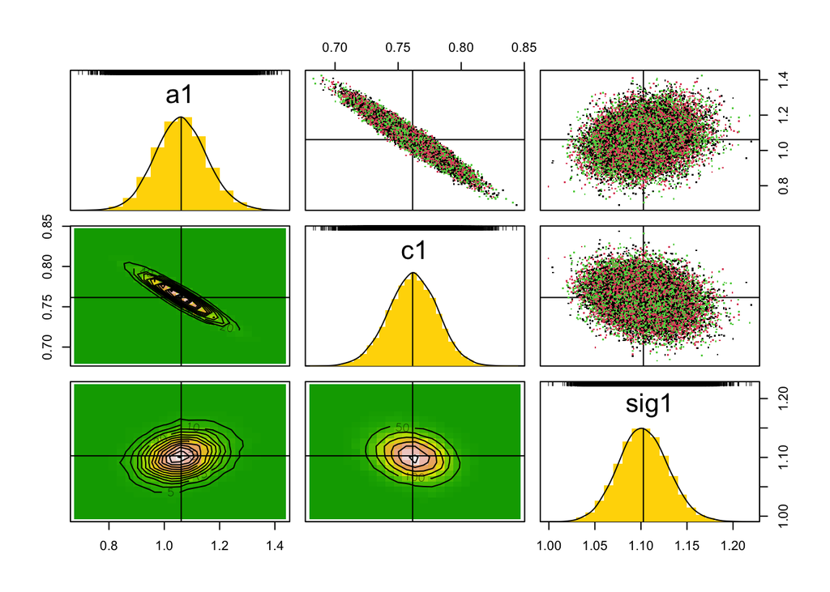

```r
pairs(dcrun.GSS)
```

```r
coef(dcrun.GSS)
```

```
##        a1        c1      sig1
## 1.0611863 0.7615269 1.1026266
```

And with these coefficients of the model, we can estimate latent population trajectories with the Kalman filter structure. This Kalman filter structure allows simultaneous estimation of latent states for observed time steps and prediction for missing ones, leveraging the temporal correlation in the process model.

```r
Kalman.pred.fn <- function() {
# Priors on model parameters: they are on the real line.
  parms ~ dmnorm(MuPost,PrecPost)
  a1 <- parms[1]
  c1 <- parms[2]
  sig1 <- parms[3]
  stovar1 <- 1/pow(sig1,2)

  # Likelihood
  mean_X1[1] <- a1/(1-c1) # Expected value of the first realization of the process
    # this is drawn from the stationary distribution of the process
    # Equation 14 (main text) and  A.4 in Appendix of Dennis et al 2006
    Varno1 <- pow(sig1,2)/(1-pow(c1,2)) #. Equation A.5 in Appendix of Dennis et al 2006

    # Updating the state: Stochastic process for all time steps
    X1[1]~dnorm(mean_X1[1], 1/Varno1); #first estimation of population
    N[1] <- exp(X1[1])
    #iteration of the GSS model in the data
    for (t in 2:qp1) {
      mean_X1[t] <- a1 + c1 * X1[(t - 1)]
      X1[t] ~ dnorm(mean_X1[t], stovar1) # Et is included here since a+cX(t-1) + Et ~ Normal(a+cX(t-1),sigma^2)
      Y1[(t-1)] ~ dpois(exp(X1[t]))
      N[t] <- exp(X1[t])
    }
}
```

```r
data4kalman <- list(qp1 = as.numeric(dc_data$Tvec[9]),
                    Y1 = array(dc_data$Y1[[9]],dim = c(as.numeric(dc_data$Tvec[9]))),
                    MuPost = coef(dcrun.GSS),
                    PrecPost = solve(vcov(dcrun.GSS)))
```

And run the Bayesian inference using the MLE from Data cloning

```r
BH_DC_Pred = jags.fit(data=data4kalman,
                      params=c("N"),
                      model=Kalman.pred.fn)
```

And we can generate a dataframe of the time series with the estimates, inter quartile range, and observed data through time

```r
summary(BH_DC_Pred)
```

```
##
## Iterations = 2001:7000
## Thinning interval = 1
## Number of chains = 3
## Sample size per chain = 5000
##
## 1. Empirical mean and standard deviation for each variable,
##    plus standard error of the mean:
##
##           Mean       SD Naive SE Time-series SE
## N[1]    96.544  159.716  1.30407        1.30576
## N[2]    44.264    6.611  0.05398        0.06997
## N[3]    91.789  138.568  1.13140        1.76920
## N[4]   140.153  335.033  2.73553        4.30293
## N[5]   164.006  386.150  3.15290        5.52368
## N[6]   162.897  350.348  2.86058        4.71406
## N[7]   128.535  190.136  1.55246        2.10532
## N[8]    74.621    8.620  0.07038        0.09038
## N[9]   199.675   13.944  0.11385        0.14326
## N[10]  298.803   17.188  0.14034        0.18033
## N[11]  101.216   10.029  0.08188        0.09987
## N[12]  199.446   13.998  0.11429        0.14601
## N[13]  219.655   14.932  0.12192        0.15529
## N[14]  199.187   14.158  0.11560        0.14471
## N[15]   56.188    7.418  0.06057        0.07857
## N[16]   97.762    9.860  0.08051        0.10354
## N[17]    7.353    2.551  0.02083        0.03704
## N[18]   58.450    7.543  0.06159        0.07773
## N[19]   45.565    6.637  0.05419        0.06637
## N[20]   68.146    8.206  0.06700        0.08828
## N[21]    8.237    2.691  0.02198        0.02872
## N[22]    5.454    2.094  0.01710        0.02212
## N[23]   23.939    4.788  0.03909        0.05060
## N[24]   20.567    4.441  0.03626        0.04667
## N[25]   12.432   14.450  0.11799        0.13142
## N[26]    3.127    1.568  0.01280        0.01806
## N[27]    3.989    1.734  0.01416        0.01834
## N[28]    3.743    1.749  0.01428        0.02038
## N[29]   14.435   22.530  0.18396        0.35555
## N[30]   34.114   77.557  0.63325        1.12079
```

[output cut: 125 more lines]

```
## N[69]   47.2593  201.429  408.702  843.277 3442.033
## N[70]  456.2157  483.828  498.736  514.164  545.263
## N[71]   43.4615  134.560  235.992  423.035 1318.526
## N[72]  100.5874  113.226  120.522  128.046  143.247
## N[73]   48.6239  152.181  268.546  472.179 1478.264
## N[74]  599.2760  631.291  648.416  665.055  697.211
## N[75]   32.6543  103.166  184.170  328.230  982.596
## N[76]   41.3094   49.535   54.314   59.581   69.985
## N[77]   29.9253   92.042  164.426  292.929  891.501
## N[78]  475.7899  502.842  518.450  534.218  565.543
## N[79]   35.5251  109.517  194.515  341.754 1074.367
## N[80]   59.9888   70.287   75.980   81.779   94.244
## N[81]   30.9263   95.888  169.711  298.669  921.191
## N[82]  360.5876  385.465  398.947  412.575  438.640
## N[83]   34.6911  140.173  289.466  599.091 2535.863
```

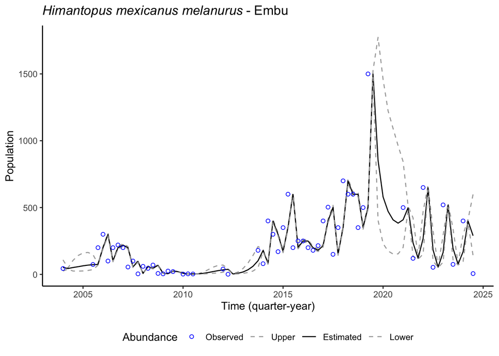

```r
# extract predictions and IQR around them
pred <- as.data.frame(t(mcmcapply(BH_DC_Pred, quantile, c(0.25, 0.5, 0.75))))
# generate range of dates for vector of time
dates_range <- seq(min(wtb_tsSS$Date), max(wtb_tsSS$Date),
                   by = "quarter")

popdyn <- as.data.frame(cbind(dates_range,pred,dc_data$Y1[[9]]))
# modify names
names(popdyn) <- c("Date", "Lower", "Estimated", "Upper", "Observed")

popdyn |>
  pivot_longer(cols = c(Lower, Estimated, Upper, Observed),
               names_to = "Abundance",
               values_to = "Count") |>
  ggplot(aes(x = Date,
             y = Count,
             color = factor(Abundance,
                            levels = c("Observed",
                                       "Upper",
                                       "Estimated",
                                       "Lower")))) +
    geom_line(aes(linetype = factor(Abundance,
                            levels = c("Observed",
                                       "Upper",
                                       "Estimated",
                                       "Lower")))) +
    geom_point(aes(shape = factor(Abundance,
                            levels = c("Observed",
                                       "Upper",
                                       "Estimated",
                                       "Lower")))) +
    labs(title = expression(italic("Himantopus mexicanus melanurus")~"- Embu"),
         x = "Time (quarter-year)",
         y = "Population",
         color = "Abundance",
         linetype = "Abundance",
         shape = "Abundance") +
    scale_linetype_manual(values = c(NA,"dashed","solid","dashed"))+
    scale_shape_manual(values = c(21, NA,NA,NA)) +
    scale_color_manual(values = c("blue","darkgray","black","darkgray")) +
    theme_classic() +
    theme(legend.position = "bottom")
```